# Raster analysis in R

Manny Gimond, Colby College

Maine GIS Educators Conference 2017, Bangor, ME

Make sure to download and install the software, packages and data onto your computer as outlined in the following section prior to attending the workshop.

# Software, packages and Data (to install prior to workshop)

## R

Version 3.4.2 is the latest version and the one used in this workshop. R is an open source data analysis and visualization programming environment whose roots go back to the [S programming language](https://en.wikipedia.org/wiki/S_%28programming_language%29) developed at Bell Laboratories in the 1970’s by [John Chambers](https://en.wikipedia.org/wiki/John_Chambers_%28statistician%29). It’s available for most operating systems including Windows, Mac and Linux.

You can download the latest version of R for Windows from https://cran.r-project.org/bin/windows/base/ and for the latest version of R for Mac got to https://cran.r-project.org/bin/macosx/

## RStudio

[RStudio](https://www.rstudio.com/products/RStudio/) is an integrated development environment (IDE) for R. It offers a user friendly interface to R by including features such as a source code editor (with colored syntax), data table viewer, git and GitHub integration and markdown output. Note that RStudio is *not needed* to run R (which has its own IDE environment–albeit not as nice as RStudio’s) but it makes using R far easier. RStudio is free software, but unlike R, it’s maintained by a private entity which also distributes a commercial version of RStudio for businesses or individuals needing customer support.

You can download the free RStudio desktop from this link https://www.rstudio.com/products/rstudio/download3/#download

## R packages

R packages are installed in the user’s home directory (C:/Users/…) by default. This is advantageous in that you do not need to have administrative privileges to install any package. But it can be a disadvantage in that if someone else logs on to the same computer where you installed a package, that person will not have access to it requiring that she install that same package in *her* home directory thereby duplicating an instance of that package on the same computer.

The following CRAN packages will be used in this workshop: `raster`, `tmap`, `rastervis`, `gstat` and `rgdal`. There are two ways you can install R packages from the CRAN repository: via the command line or via the RStudio interface.

### Package installation option 1

For the command line approach simply run the following lines of code in an R console:

```r
install.packages("raster")
install.packages("tmap")
install.packages("rastervis")
install.packages("gstat")
install.packages("rgdal")
```

Note that most of these packages have dependencies, but these dependencies are automatically loaded for you.

### Package installation option 2

Packages can also be installed via the RStudio interface. To install a CRAN package from within RStudio, click on the *Packages* tab, select *Install* and choose *Repository (CRAN, CRANextra)* as the source location. In the following example, the package `raster` is installed from CRAN.

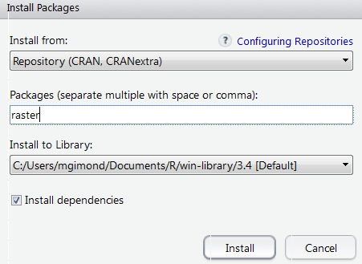

```r
knitr::include_graphics("Figures/Install_CRAN_packages.png")
```

## Data

Data used in this workshop can be downloaded from https://mgimond.github.io/megug2017/data.zip then extracted into a folder for use in the workshop.

# Workshop tutorial is forthcoming (check back soon)